# Aufgaben Vorlesung 2

Dr. Meike Wocken

2022-10-22

# Aufgabe 6

Verwenden Sie bitte den gegebenen Datensatz Auto aus dem R Paket ISLR.

```r
library(ISLR)
library(tidyverse)
?Auto
Auto <- tibble(Auto)
```

## a) Test- und Trainingsdaten

Unterteilen Sie den Datensatz bitte in einen Test- und einen Trainingsdatensatz. Schätzen Sie bitte das Modell
$$mpg = \beta_0 + \beta_1 cylinders + \beta_2
displacement + \beta_3 horsepower + \beta_4 weight + \epsilon$$
und berechnen den RMSE jeweils auf Test- und Trainingsdaten.

### Sample für Trainingsdatensatz ziehen

```r
set.seed (321)
# Anzahl Beobachtungen
n_total <- nrow(Auto)

# Sample ziehen
index <- sample(n_total, size=trunc(.5 * n_total))

Auto_train_data <- Auto %>%
  filter(row_number() %in% index)

Auto_test_data <- Auto %>%
  filter(!(row_number() %in% index))
```

### Modell schätzen

Wir schätzen ein lineares Modell. Das Ergebnis ist wieder ein Objekt. Der Summary-Befehl zeigt Schätzer, Informationen zur Anpassungsgüte und den Parametern an.

```r
auto_lm_train <- lm(data = Auto_train_data, mpg ~ cylinders + displacement + horsepower  + weight)

auto_lm_train %>% summary()
```

```
##
## Call:
## lm(formula = mpg ~ cylinders + displacement + horsepower + weight,
##     data = Auto_train_data)
##
## Residuals:
##     Min      1Q  Median      3Q     Max
## -8.6851 -2.6896 -0.4971  2.2467 16.0424
##
## Coefficients:
##                Estimate Std. Error t value Pr(>|t|)
## (Intercept)  46.3654705  2.1619554  21.446  < 2e-16 ***
## cylinders    -0.1468376  0.5810603  -0.253  0.80077
## displacement  0.0014996  0.0129522   0.116  0.90795
## horsepower   -0.0553032  0.0185942  -2.974  0.00332 **
## weight       -0.0055710  0.0009751  -5.714 4.19e-08 ***
## ---
## Signif. codes:  0 '***' 0.001 '**' 0.01 '*' 0.05 '.' 0.1 ' ' 1
##
## Residual standard error: 4.208 on 191 degrees of freedom
## Multiple R-squared:  0.6978, Adjusted R-squared:  0.6915
## F-statistic: 110.3 on 4 and 191 DF,  p-value: < 2.2e-16
```

### RMSE (Root Mean Squared Error) für Trainingsdaten berechnen

RMSE für Trainingsdaten ausgeben lassen.

```r
# Residuen
auto_res <- auto_lm_train %>%
   residuals()
# Anzahl Beobachtungen
n_train <- nrow(Auto_train_data)
# RMSE
sqrt(sum(auto_res^2)/n_train)
```

```
## [1] 4.153614
```

RMSE für Testdaten berechnen, zuerst müssen dafür die Werte mit dem geschätzten Modell prognostiziert werden. Dann wird der RMSE ermittelt.

```r
# Testdaten mit dem Modell anpassen
auto_test_fit <- predict(auto_lm_train, Auto_test_data)
auto_test_res <- Auto_test_data$mpg - auto_test_fit

# Anzahl Beobachtungen
n_test <- nrow(Auto_test_data)

# RMSE
sqrt(sum(auto_test_res^2)/n_test)
```

```
## [1] 4.297121
```

```r
# zu einem Datenobjekt zusammenfuegen für ggplot
Auto_test_total <- tibble(Auto_test_data, fitted = auto_test_fit, residuals = auto_test_res)
```

## b) Residuen

Residuen darstellen in Test- und Trainingsdaten. Das Modell liefert als Ergebnis die angepassten Werte (fitted values) und die Residuen mit (Argumente des Modellergebnisses).

Residuen müssen immer zufällig sein. Auch sollten beobachtete und angepasste Daten um die Winkelhalbierende zufällig verteilt sein. Würden Punkte exakt auf der Winkelhalbierende liegen, wäre es die perfekte Prognose, denn dann wären prognostizierte Werte gleich beobachteter Werte.

Wir sehen, dass die Abweichungen nicht zufällig sind, das Modell scheint nicht zu passen!

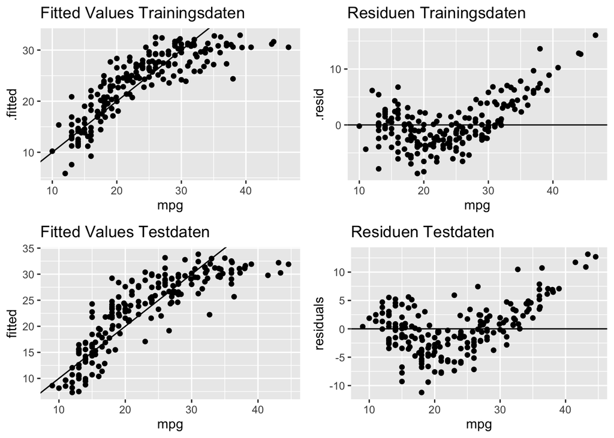

```r
library(ggplot2)
# fuer mehrere Plots in einer ausgabe
library(ggpubr)
# paket fuer augment: hinzufuegen weiterer Infos eg fitted und residuals
library(broom)



# Fitted values der trainingsdaten
train.1 <- ggplot(augment(auto_lm_train), aes(x= mpg, y= .fitted)) +
                geom_point() +
                geom_abline(intercept = 0, slope = 1) +
                ggtitle("Fitted Values Trainingsdaten")

# Residuen der trainingsdaten
train.2 <- ggplot(augment(auto_lm_train), aes(x= mpg, y=.resid)) +
                geom_point() +
                geom_hline(yintercept = 0) +
                ggtitle("Residuen Trainingsdaten")

# Fitted values der testdaten
test.1 <- ggplot(Auto_test_total, aes(x= mpg, y=fitted)) +
                geom_point() +
                geom_abline(intercept = 0, slope = 1) +
                ggtitle("Fitted Values Testdaten")

# Residuen der testdaten
test.2 <- ggplot(Auto_test_total, aes(x= mpg, y=residuals)) +
                geom_point() +
                geom_hline(yintercept = 0) +
                ggtitle("Residuen Testdaten")

ggarrange(train.1, train.2, test.1, test.2, ncol=2, nrow=2)
```

## c) Korrelation

Für ein besseres Verständnis der Daten und welches Modell passen könnte, werden nun Korrelationen zwischen den Variablen berechnet und Streudiagramme verwendet.

Wir sehen eine hohe Korrelation von cylinders und displacement, cylinders und horsepower, displacement und horsepower.

```r
Auto %>%
  select(mpg , cylinders, displacement, horsepower) %>%
  cor()
```

```
##                     mpg  cylinders displacement horsepower
## mpg           1.0000000 -0.7776175   -0.8051269 -0.7784268
## cylinders    -0.7776175  1.0000000    0.9508233  0.8429834
## displacement -0.8051269  0.9508233    1.0000000  0.8972570
## horsepower   -0.7784268  0.8429834    0.8972570  1.0000000
```

Streudiagramm zeigt auch noch einmal Zusammenhang auf.

```r
library(GGally)
```

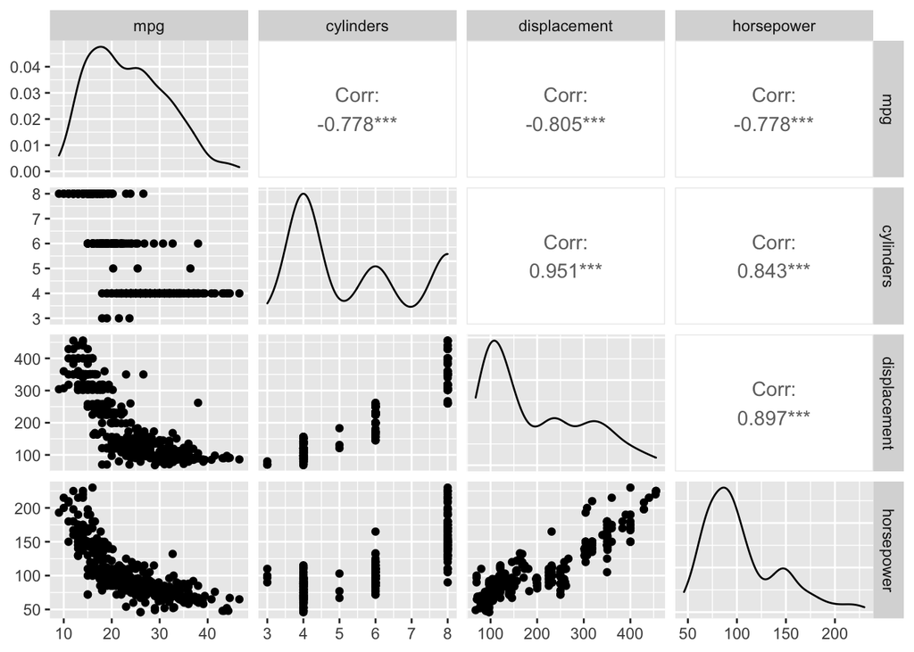

```r
Auto %>%
  select(mpg , cylinders, displacement, horsepower) %>%
  ggpairs ()
```

Der individuelle Effekt $\widehat \beta_k$ kann bei hohen Korrelationen nicht gut separiert werden.

Theorie: Horsepower wird von Hubraum (displaccement) und weiteren Faktoren beeinflusst (Motor: Turbolader etc.). Horsepower auch hoch korreliert mit Gewicht 1, 0.8645377, 0.8645377, 1, daher jetzt nur noch Horsepower zur Erklärung.

Der Zusammenhang scheint nicht linear zu sein, dennoch kann mit einem linearen Modell gestartet werden.

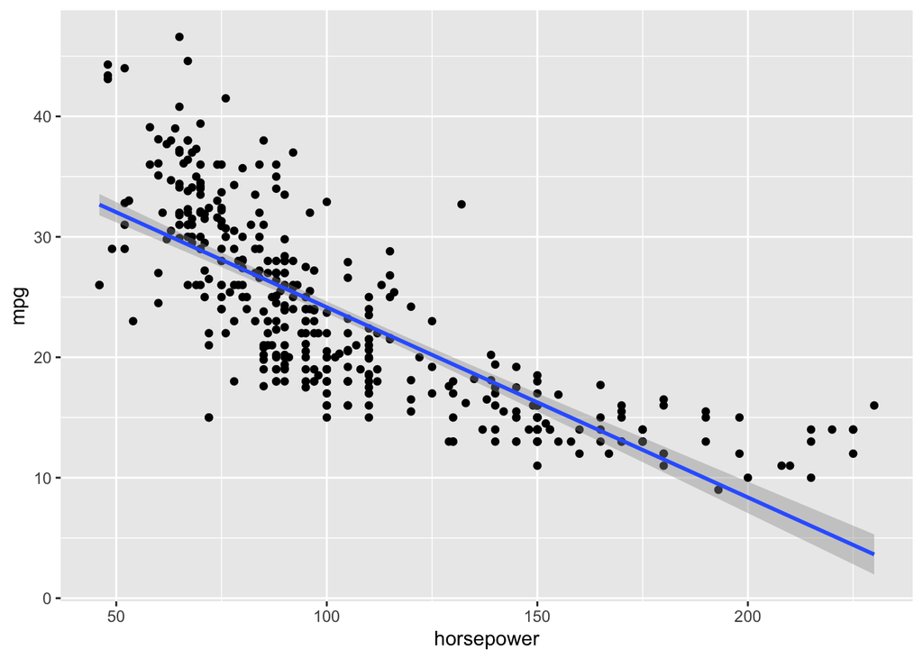

```r
ggplot(Auto, aes(x=horsepower, y=mpg)) +
  geom_point() +
  geom_smooth(method='lm', formula= y~x)
```

## d) verbessertes Modell

Es soll ein verbessertes Modell geschätzt werden. Es wird nur horsepower verwendet.

```r
auto_lm_train_2 <- lm(data = Auto_train_data, mpg ~ horsepower)

auto_lm_train_2 %>% summary()
```

```
##
## Call:
## lm(formula = mpg ~ horsepower, data = Auto_train_data)
##
## Residuals:
##     Min      1Q  Median      3Q     Max
## -8.3325 -3.3349 -0.4646  2.4835 16.6691
##
## Coefficients:
##              Estimate Std. Error t value Pr(>|t|)
## (Intercept) 40.327805   1.037358   38.88   <2e-16 ***
## horsepower  -0.159953   0.009521  -16.80   <2e-16 ***
## ---
## Signif. codes:  0 '***' 0.001 '**' 0.01 '*' 0.05 '.' 0.1 ' ' 1
##
## Residual standard error: 4.847 on 194 degrees of freedom
## Multiple R-squared:  0.5926, Adjusted R-squared:  0.5905
## F-statistic: 282.2 on 1 and 194 DF,  p-value: < 2.2e-16
```

Es werden die Residuen geprüft. Die Residuen sind immer noch nicht zufällig!

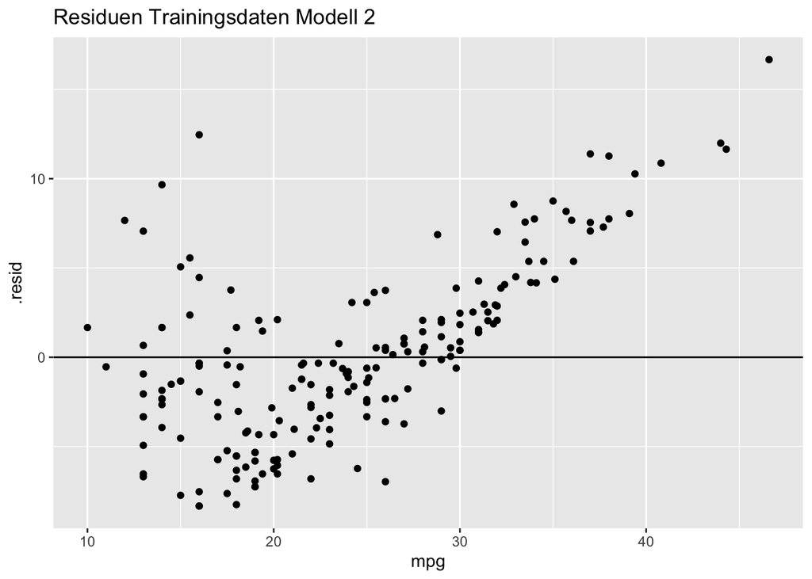

```r
ggplot(augment(auto_lm_train_2), aes(x= mpg, y=.resid)) +
                geom_point() +
                geom_hline(yintercept = 0) +
                ggtitle("Residuen Trainingsdaten Modell 2")
```

Es wird nun ein weiteres Modell geschätzt, das eine neue Variable aufnimmt: horsepower zum Quadrat. Es könnte auch eine neue transformierte Variable in das Modell aufgenommen werden, die Methode **I()** zur Formulierung der Formel vereinfacht aber das Handling der Test-/Trainingsdaten in R.

```r
auto_lm_train_3 <- lm(data = Auto_train_data, mpg ~ horsepower + I(horsepower^2))

auto_lm_train_3 %>% summary()
```

```
##
## Call:
## lm(formula = mpg ~ horsepower + I(horsepower^2), data = Auto_train_data)
##
## Residuals:
##      Min       1Q   Median       3Q      Max
## -12.8020  -2.8160  -0.1293   1.9702  14.3122
##
## Coefficients:
##                   Estimate Std. Error t value Pr(>|t|)
## (Intercept)     58.4954748  2.5274145  23.144  < 2e-16 ***
## horsepower      -0.4884598  0.0434483 -11.242  < 2e-16 ***
## I(horsepower^2)  0.0013118  0.0001703   7.704 6.72e-13 ***
## ---
## Signif. codes:  0 '***' 0.001 '**' 0.01 '*' 0.05 '.' 0.1 ' ' 1
##
## Residual standard error: 4.25 on 193 degrees of freedom
## Multiple R-squared:  0.6884, Adjusted R-squared:  0.6852
## F-statistic: 213.2 on 2 and 193 DF,  p-value: < 2.2e-16
```

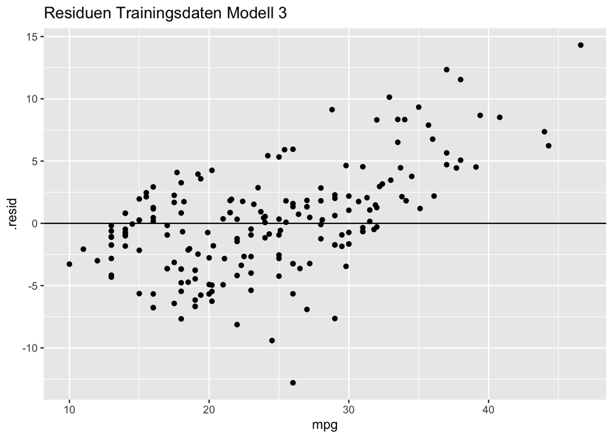

```r
ggplot(augment(auto_lm_train_3), aes(x= mpg, y=.resid)) +
                geom_point() +
                geom_hline(yintercept = 0) +
                ggtitle("Residuen Trainingsdaten Modell 3")
```

```r
library(magrittr)
auto_lm_train_3 %>%
  augment() %$%
  sqrt(sum(.resid^2)/n_train)
```

```
## [1] 4.217343
```

```r
# Testdaten
auto_test_fit_3 <- predict(auto_lm_train_3, Auto_test_data)
auto_test_res_3 <- Auto_test_data$mpg - auto_test_fit_3

# RMSE
sqrt(sum(auto_test_res_3^2)/n_test)
```

```
## [1] 4.515457
```

# Aufgabe 8

Datensatz Hitter aus dem R Paket ISLR: Mithilfe des Datensatzes soll das Gehalt eines Baseball Spielers basierend auf verschiedenen Spieler-Statistiken und der Vorjahres-Leistung geschätzt werden. Führen Sie eine Forward-Selektion zur Auswahl eines finalen Modells durch. Interpretieren Sie das Modellergebnis.

Informationen zum Datensatz

```r
?Hitters
```

Dimension des Datensatzes 322 x 20

```r
Hitters <- tibble(Hitters )
Hitters
```

```
## # A tibble: 322 × 20
##    AtBat  Hits HmRun  Runs   RBI Walks Years CAtBat CHits CHmRun CRuns  CRBI
##    <int> <int> <int> <int> <int> <int> <int>  <int> <int>  <int> <int> <int>
##  1   293    66     1    30    29    14     1    293    66      1    30    29
##  2   315    81     7    24    38    39    14   3449   835     69   321   414
##  3   479   130    18    66    72    76     3   1624   457     63   224   266
##  4   496   141    20    65    78    37    11   5628  1575    225   828   838
##  5   321    87    10    39    42    30     2    396   101     12    48    46
##  6   594   169     4    74    51    35    11   4408  1133     19   501   336
##  7   185    37     1    23     8    21     2    214    42      1    30     9
##  8   298    73     0    24    24     7     3    509   108      0    41    37
##  9   323    81     6    26    32     8     2    341    86      6    32    34
## 10   401    92    17    49    66    65    13   5206  1332    253   784   890
## # … with 312 more rows, and 8 more variables: CWalks <int>, League <fct>,
## #   Division <fct>, PutOuts <int>, Assists <int>, Errors <int>, Salary <dbl>,
## #   NewLeague <fct>
```

Zusammenfassende Statistiken. Wir erkennen: Salary hat NA Werte.

```r
Hitters %>%
  summary()
```

```
##      AtBat            Hits         HmRun            Runs
##  Min.   : 16.0   Min.   :  1   Min.   : 0.00   Min.   :  0.00
##  1st Qu.:255.2   1st Qu.: 64   1st Qu.: 4.00   1st Qu.: 30.25
##  Median :379.5   Median : 96   Median : 8.00   Median : 48.00
##  Mean   :380.9   Mean   :101   Mean   :10.77   Mean   : 50.91
##  3rd Qu.:512.0   3rd Qu.:137   3rd Qu.:16.00   3rd Qu.: 69.00
##  Max.   :687.0   Max.   :238   Max.   :40.00   Max.   :130.00
##
##       RBI             Walks            Years            CAtBat
##  Min.   :  0.00   Min.   :  0.00   Min.   : 1.000   Min.   :   19.0
##  1st Qu.: 28.00   1st Qu.: 22.00   1st Qu.: 4.000   1st Qu.:  816.8
##  Median : 44.00   Median : 35.00   Median : 6.000   Median : 1928.0
##  Mean   : 48.03   Mean   : 38.74   Mean   : 7.444   Mean   : 2648.7
##  3rd Qu.: 64.75   3rd Qu.: 53.00   3rd Qu.:11.000   3rd Qu.: 3924.2
##  Max.   :121.00   Max.   :105.00   Max.   :24.000   Max.   :14053.0
##
##      CHits            CHmRun           CRuns             CRBI
##  Min.   :   4.0   Min.   :  0.00   Min.   :   1.0   Min.   :   0.00
##  1st Qu.: 209.0   1st Qu.: 14.00   1st Qu.: 100.2   1st Qu.:  88.75
##  Median : 508.0   Median : 37.50   Median : 247.0   Median : 220.50
##  Mean   : 717.6   Mean   : 69.49   Mean   : 358.8   Mean   : 330.12
##  3rd Qu.:1059.2   3rd Qu.: 90.00   3rd Qu.: 526.2   3rd Qu.: 426.25
##  Max.   :4256.0   Max.   :548.00   Max.   :2165.0   Max.   :1659.00
##
##      CWalks        League  Division    PutOuts          Assists
##  Min.   :   0.00   A:175   E:157    Min.   :   0.0   Min.   :  0.0
##  1st Qu.:  67.25   N:147   W:165    1st Qu.: 109.2   1st Qu.:  7.0
##  Median : 170.50                    Median : 212.0   Median : 39.5
##  Mean   : 260.24                    Mean   : 288.9   Mean   :106.9
##  3rd Qu.: 339.25                    3rd Qu.: 325.0   3rd Qu.:166.0
##  Max.   :1566.00                    Max.   :1378.0   Max.   :492.0
##
##      Errors          Salary       NewLeague
##  Min.   : 0.00   Min.   :  67.5   A:176
##  1st Qu.: 3.00   1st Qu.: 190.0   N:146
##  Median : 6.00   Median : 425.0
##  Mean   : 8.04   Mean   : 535.9
##  3rd Qu.:11.00   3rd Qu.: 750.0
##  Max.   :32.00   Max.   :2460.0
##                  NA's   :59
```

Aufgrund der Fehlwerte in Salary werden die Zeilen mit nicht vollständigen Beobachtungen entfernt. Durch die Zuweisung auf Hitters selber, wird der Datensatz (ohne Fehlermeldung!) einfach überschrieben.

```r
Hitters <- Hitters %>%
            filter(Salary != "NA" )
```

## Forward-Selection

Für Forward Selection gibt es bereits implementierte Algorithmen, z.B. in **leaps**.

Asteriks zeigt an, welche Variablen in dem Modell sind z.B. das beste Modell mit zwei Variablen hat CRBI und Hits als erklärende Variablen.

```r
library(leaps)
salary.fwd = regsubsets(Salary~.,data=Hitters ,nvmax =19,
                        method ="forward")
summary(salary.fwd)
```

```
## Subset selection object
## Call: regsubsets.formula(Salary ~ ., data = Hitters, nvmax = 19, method = "forward")
## 19 Variables  (and intercept)
##            Forced in Forced out
## AtBat          FALSE      FALSE
## Hits           FALSE      FALSE
## HmRun          FALSE      FALSE
## Runs           FALSE      FALSE
## RBI            FALSE      FALSE
## Walks          FALSE      FALSE
## Years          FALSE      FALSE
## CAtBat         FALSE      FALSE
## CHits          FALSE      FALSE
## CHmRun         FALSE      FALSE
## CRuns          FALSE      FALSE
## CRBI           FALSE      FALSE
## CWalks         FALSE      FALSE
## LeagueN        FALSE      FALSE
## DivisionW      FALSE      FALSE
## PutOuts        FALSE      FALSE
## Assists        FALSE      FALSE
## Errors         FALSE      FALSE
## NewLeagueN     FALSE      FALSE
## 1 subsets of each size up to 19
## Selection Algorithm: forward
##           AtBat Hits HmRun Runs RBI Walks Years CAtBat CHits CHmRun CRuns CRBI
## 1  ( 1 )  " "   " "  " "   " "  " " " "   " "   " "    " "   " "    " "   "*"
## 2  ( 1 )  " "   "*"  " "   " "  " " " "   " "   " "    " "   " "    " "   "*"
## 3  ( 1 )  " "   "*"  " "   " "  " " " "   " "   " "    " "   " "    " "   "*"
## 4  ( 1 )  " "   "*"  " "   " "  " " " "   " "   " "    " "   " "    " "   "*"
## 5  ( 1 )  "*"   "*"  " "   " "  " " " "   " "   " "    " "   " "    " "   "*"
## 6  ( 1 )  "*"   "*"  " "   " "  " " "*"   " "   " "    " "   " "    " "   "*"
## 7  ( 1 )  "*"   "*"  " "   " "  " " "*"   " "   " "    " "   " "    " "   "*"
## 8  ( 1 )  "*"   "*"  " "   " "  " " "*"   " "   " "    " "   " "    "*"   "*"
## 9  ( 1 )  "*"   "*"  " "   " "  " " "*"   " "   "*"    " "   " "    "*"   "*"
## 10  ( 1 ) "*"   "*"  " "   " "  " " "*"   " "   "*"    " "   " "    "*"   "*"
## 11  ( 1 ) "*"   "*"  " "   " "  " " "*"   " "   "*"    " "   " "    "*"   "*"
## 12  ( 1 ) "*"   "*"  " "   "*"  " " "*"   " "   "*"    " "   " "    "*"   "*"
## 13  ( 1 ) "*"   "*"  " "   "*"  " " "*"   " "   "*"    " "   " "    "*"   "*"
## 14  ( 1 ) "*"   "*"  "*"   "*"  " " "*"   " "   "*"    " "   " "    "*"   "*"
```

[output cut: 10 more lines]

```
## 5  ( 1 )  " "    " "     "*"       "*"     " "     " "    " "
## 6  ( 1 )  " "    " "     "*"       "*"     " "     " "    " "
## 7  ( 1 )  "*"    " "     "*"       "*"     " "     " "    " "
## 8  ( 1 )  "*"    " "     "*"       "*"     " "     " "    " "
## 9  ( 1 )  "*"    " "     "*"       "*"     " "     " "    " "
## 10  ( 1 ) "*"    " "     "*"       "*"     "*"     " "    " "
## 11  ( 1 ) "*"    "*"     "*"       "*"     "*"     " "    " "
## 12  ( 1 ) "*"    "*"     "*"       "*"     "*"     " "    " "
## 13  ( 1 ) "*"    "*"     "*"       "*"     "*"     "*"    " "
## 14  ( 1 ) "*"    "*"     "*"       "*"     "*"     "*"    " "
## 15  ( 1 ) "*"    "*"     "*"       "*"     "*"     "*"    " "
## 16  ( 1 ) "*"    "*"     "*"       "*"     "*"     "*"    " "
## 17  ( 1 ) "*"    "*"     "*"       "*"     "*"     "*"    "*"
## 18  ( 1 ) "*"    "*"     "*"       "*"     "*"     "*"    "*"
## 19  ( 1 ) "*"    "*"     "*"       "*"     "*"     "*"    "*"
```

Welches Modell ist nun zu wählen? Dafür wird einmal geschaut, welche Argumente der Forward Selection ALgorithmus mitgibt.

```r
?regsubsets
```

Wir schauen uns die korrigierten $R^2$ an.

```r
summary(salary.fwd)$adjr2
```

```
##  [1] 0.3188503 0.4208024 0.4450753 0.4672734 0.4808971 0.4972001 0.4998663
##  [8] 0.5132768 0.5180572 0.5222606 0.5225706 0.5217245 0.5206736 0.5195431
## [15] 0.5178661 0.5162219 0.5144464 0.5126097 0.5106270
```

**which.max()** gibt den Index des maximalen Werts zurück

```r
which.max(summary(salary.fwd)$adjr2)
```

```
## [1] 11
```

Wir erhalten nun die Koeffizienten des besten Modells mit dem Befehl coef(). Wichtig: backward und forward-Methoden können unterschiedliche Ergebnisse in der Modellselektion haben.

```r
coef(salary.fwd, 11)
```

```
##  (Intercept)        AtBat         Hits        Walks       CAtBat        CRuns
##  135.7512195   -2.1277482    6.9236994    5.6202755   -0.1389914    1.4553310
##         CRBI       CWalks      LeagueN    DivisionW      PutOuts      Assists
##    0.7852528   -0.8228559   43.1116152 -111.1460252    0.2894087    0.2688277
```

Interpretation des Modells, z.B, der Effekt von **Hits**:

Nimmt Anzahl von Hits um eine Einheit zu ( 1 Hit), so steigt **ceteris paribus (c.p.)** das **durchschnittliche** Gehalt um 6,924 T US Dollar. Ob dieser Effekt statistisch signifikant ist, wird nächste Vorlesung behandelt.

# Zusatzaufgabe zu kategorialen Daten

Ladet das Single Resident Apartment Dataset von letzter Stunde.

```r
mydata <- read_tsv("../../Daten/hh111/hh111.ann.txt",
                   col_names = c("timestamp", "name.of.sensor",
                                 "room.level", "room.detail", "message", "sensor.type",
                                  "classes"))
mydata
```

```
## # A tibble: 351,353 × 7
##    timestamp           name.of.sensor room.level room.…¹ message senso…² classes
##    <dttm>              <chr>          <chr>      <chr>   <chr>   <chr>   <chr>
##  1 2011-06-15 00:09:20 M020           Bedroom    Bedroom ON      Contro… Other_…
##  2 2011-06-15 00:09:21 M020           Bedroom    Bedroom OFF     Contro… Other_…
##  3 2011-06-15 00:09:22 M020           Bedroom    Bedroom ON      Contro… Other_…
##  4 2011-06-15 00:09:24 M020           Bedroom    Bedroom OFF     Contro… Other_…
##  5 2011-06-15 00:09:33 LS020          Ignore     Ignore  0       Contro… Other_…
##  6 2011-06-15 00:09:33 M020           Bedroom    Bedroom ON      Contro… Other_…
##  7 2011-06-15 00:09:34 LS022          Ignore     Ignore  0       Contro… Other_…
##  8 2011-06-15 00:09:34 M022           Bedroom    Bed     ON      Contro… Other_…
##  9 2011-06-15 00:09:34 M020           Bedroom    Bedroom OFF     Contro… Other_…
## 10 2011-06-15 00:09:36 M022           Bedroom    Bed     OFF     Contro… Other_…
## # … with 351,343 more rows, and abbreviated variable names ¹room.detail,
## #   ²sensor.type
```

```r
mydata.subset <- mydata %>%
    filter(sensor.type == "Control4-Temperature" & room.detail != "Ignore" ) %>%
    select(message, classes)

mydata.subset %>% head()
```

```
## # A tibble: 6 × 2
##   message classes
##   <chr>   <chr>
## 1 24      Sleep
## 2 23      Sleep
## 3 23      Sleep
## 4 24      Sleep
## 5 23      Sleep
## 6 24      Personal_Hygiene
```

Die Spalte message hat den Typ chr (Character). Es muss in einen numerischen Wert gewandelt werden. Außerdem brauchen wir eine Dummy-Variable, die aus 0 und 1 besteht. Da ich euch gerne zeigen möchte, dass R bei einer Klasse mit den Factoren sehr gut mitdenkt, wird in case_when() wieder ein Character-Vektor erzeugt mit Einträgen Breakfast, Dinner und NA.

```r
mydata.subset <- mydata.subset  %>%
  mutate(message = as.numeric(message)) %>%
  mutate(
    dinner = case_when(
    classes == "Cook_Breakfast" | classes == "Eat_Breakfast" ~ "Breakfast",
    classes == "Cook_Dinner" | classes == "Eat_Dinner" ~ "Dinner"))

mydata.subset
```

```
## # A tibble: 1,367 × 3
##    message classes          dinner
##      <dbl> <chr>            <chr>
##  1      24 Sleep            <NA>
##  2      23 Sleep            <NA>
##  3      23 Sleep            <NA>
##  4      24 Sleep            <NA>
##  5      23 Sleep            <NA>
##  6      24 Personal_Hygiene <NA>
##  7      24 Eat_Breakfast    Breakfast
##  8      23 Other_Activity   <NA>
##  9      23 Other_Activity   <NA>
## 10      24 Other_Activity   <NA>
## # … with 1,357 more rows
```

Es wird nun mit einem linearen Modell der durchschnittliche Unterschied der Temperaturen zwischen Breakfast und Dinner geschätzt. Wir nehmen unsere neue Variabale dinner als erklärende Variable auf. R behandelt die Variable korrekt und formt es zu einer Dummy Variable mit 0 und 1. R hat dabei Dinner als 1 hinterlegt (siehe Name des Coefficients) und Breakfast als 0. Das Regressionsergebnis zeigt, dass im Durchschnitt die Temperatur beim Frühstück 23,636 ist (Dinner = 0, das Modell besteht für Breakfast nur aus der Konstanten). Im Durchschnitt ist die Temperatur beim Dinner 1,9261 Einheiten höher. Die Interpretation des Steigungsparameters ist immer ein Vergleich zur Basis-Kategorie. In unserem Fall also Breakfast.

```r
mydata.subset  %>%
  lm(message ~ dinner, .) %>% summary()
```

```
##
## Call:
## lm(formula = message ~ dinner, data = .)
##
## Residuals:
##     Min      1Q  Median      3Q     Max
## -1.6364 -0.5994  0.3636  0.4375  2.4375
##
## Coefficients:
##              Estimate Std. Error t value Pr(>|t|)
## (Intercept)   23.6364     0.3103  76.166  < 2e-16 ***
## dinnerDinner   1.9261     0.4031   4.778 6.62e-05 ***
## ---
## Signif. codes:  0 '***' 0.001 '**' 0.01 '*' 0.05 '.' 0.1 ' ' 1
##
## Residual standard error: 1.029 on 25 degrees of freedom
##   (1340 Beobachtungen als fehlend gelöscht)
## Multiple R-squared:  0.4773, Adjusted R-squared:  0.4564
## F-statistic: 22.83 on 1 and 25 DF,  p-value: 6.623e-05
```

Im Skript findet ihr eine weitere Aufgabe für drei Klassen. Hier müssen dann zwei Dummy Variablen gebildet werden.